[interactive chart not shown]

EPOL 590 · Lecture 1 · Monday 19 October 2026

# AI and Academic Literature

Research questions, and where a literature review begins

Professor Liam Magee · Education Policy, Organization and Leadership · University of Illinois Urbana-Champaign

Welcome

## Do we need another course on academic literature?

Foundational

### How to develop a literature review

Build, annotate, analyze, map, and turn a body of literature into an argument.

Future-oriented

### How AI is changing scholarship

What AI makes easier, what it hides, and what responsibility stays with the researcher.

EPOL 590 · Lecture 1 · A mix of theory and practice

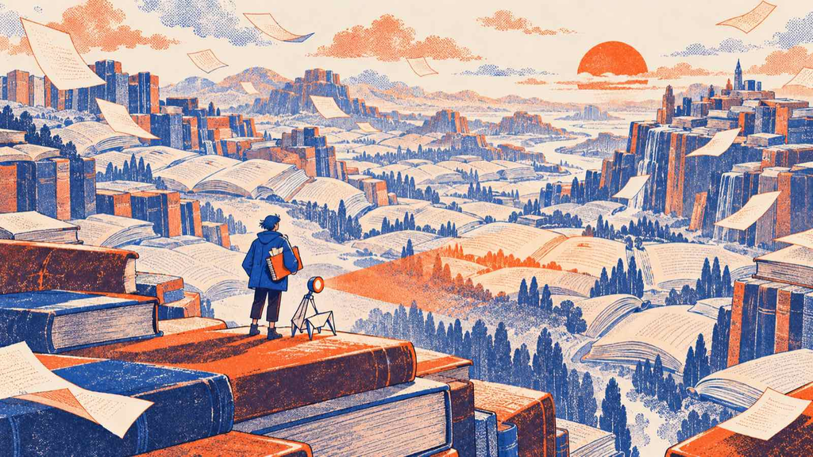

The course in one sentence

## How do you build a sense of your field, and its gaps?

*Academic literature* is at once mundane and mystical. We start with fundamentals — building, annotating, mapping, writing — then ask how AI can make interpretation more critical, analytic and reflexive.

Tonight · 5:00–7:50 PM Central

## The plan for this session

5:00

Welcome, the course and how it’s assessed

5:30

Introductions

6:00

Break

6:10

What is academic literature? The response board

6:30

Your research record and the class document

6:40

What makes a good research question?

7:00

Break

7:10

Breakouts: a candidate question, then report back

7:40

Wrap-up: class map, baseline reflection, Task 1

Two ten-minute breaks, on the hour · Times are a guide

Seven Mondays · 5:00–7:50 PM Central · online

## What we’ll cover

| Session | Seminar | Focus | Task due (Mon) |
| --- | --- | --- | --- |
| 1 | 19 Oct | Research questions and academic literature | Task 1 · 26 Oct |
| 2 | 26 Oct | Article anatomy, review design, mapping a field | Task 2 · 2 Nov |
| 3 | 2 Nov | AI-assisted close and distant reading | Task 3 · 9 Nov |
| 4 | 9 Nov | Difficult texts, audiences, scholarly voice | Task 4 · 16 Nov |
| 5 | 16 Nov | Structure, signposting, scholarly communities | Task 5 · 30 Nov |
| — | 23 Nov | Fall break: no seminar, nothing due | — |
| 6 | 30 Nov | Reflexivity, positionality and AI in scholarship | Task 6 · 7 Dec |
| 7 | 7 Dec | Future of scholarship; final review workshop | — |
| Final | — | Final literature review, Tue 15 Dec, 11:59 PM | Task 7 · 15 Dec |

All deadlines 11:59 PM Central, submitted on Canvas · Matches the syllabus and Canvas modules

Assessment · 50% staged · 10% peer review

## A mock (or real) literature review

1 · Ungraded · Mon 26 Oct

### Research topic and question

2 · 10% · Mon 2 Nov

### Review design, method and scope

3 · 10% · Mon 9 Nov

### Conceptual map of the literature

4 · 10% · Mon 16 Nov

### Literature review writing sample

5 · 10% · Mon 30 Nov

### Structured draft and signposting

6 · 10% · Mon 7 Dec

### AI-use statement and reflexive commentary

Each task builds the same review. Task 1 is ungraded: feedback before any marks. After Tasks 4 and 6 you review classmates’ work, 5% each, complete or incomplete.

Task names match Canvas · 11:59 PM Central · plus an ungraded baseline reflection this week

40%

Task 7 · Final review or course outline

## Tuesday 15 December, 11:59 PM Central

A literature review, or a course outline for teaching how to write one. 1,500–2,000 words, with an AI-use statement and a short revision memo.

Assessment criteria

## What we’re looking for, every task

01

Significance and feasibility of the question

02

Relevance and traceability of sources

03

Quality of interpretation and synthesis

04

Clear organization, framing and scholarly voice

05

Reflexivity and responsible, transparent AI use

06

Responsiveness to evidence and feedback

From the syllabus · Task-specific rubrics on Canvas

Approach

## Move fast, but think harder

### Sketch, then revise

- Quick sketches of a literature review, with AI and its caveats
- Build intuitions for reviewing and writing up fast
- Peer review turns a lonely pursuit into a social one

### A critical lens on AI

- Knowledge has always been technical: paper, press, media, the internet
- Ask how outputs were made and whose knowledge they privilege
- Technology should make us work harder, not easier

EPOL 590 · Lecture 1

Format

## How a Monday runs

3 h

Used flexibly: mini-lectures, discussion, group work and AI exercises

2 × 10

Minute breaks, on the hour

~20 h

Per active week in total, including reading, searching and writing

Most of each week’s task starts in the room. Together we’ll build a lightweight notebook of good search, reading and review practices.

EPOL 590 · Lecture 1

Introductions · about 90 seconds each

## Who’s here?

1 Your name, and your program or department

2 Your field, or a research interest

3 A question you might pursue this term

4 One way you’ve used AI in your research

A rough question is fine. We will spend the term sharpening it.

EPOL 590 · Lecture 1

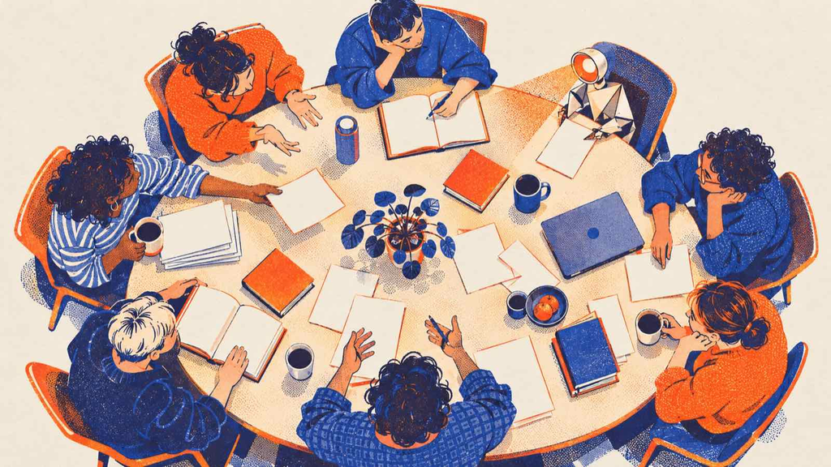

Discussion and introductions

## What is a literature review?

## What is AI changing?

Introduce yourself, your field, and one thing you’ve used AI for in research.

[interactive chart not shown]

Respond now · then we discuss

## What is academic literature?

1 Open the response board from the link in the Zoom chat.

2 Answer in a sentence or two. A name is optional.

3 Watch themes form as answers share words, then we read them together.

[Open the response board →](https://machinespirits.org/590-fall-2026/respond#what-is-academic-literature)

Your research record

## Keep notes you can explain your review from

### Note-taking software

Obsidian or similar; learn Markdown and try a Zettelkasten. Ask me about NightOwl.

### A reference manager

Zotero or any reliable way to keep full citations with your notes.

### A running log

Question, search decisions, maps, drafts, feedback and AI-use notes.

No particular commercial tool is required

Working together

## One continuous class document

### What we need

- A single running document for the term
- Sharing and annotation with peers
- Institution-supported, shared only with named people

### What stays in Canvas

- Submissions and grades
- Private instructor feedback
- Announcements and readings

2026 class workspace: “EPOL 590 Fall 2026” Google Doc · linked on Canvas

Don’t put confidential, identifiable or restricted material into any AI service

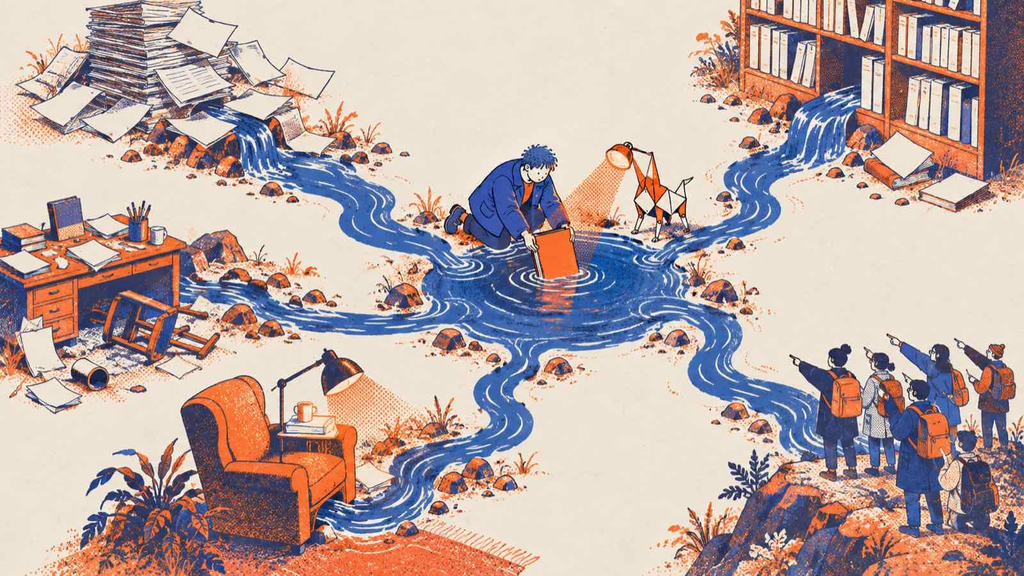

What makes a good research question?

## Where questions come from

**Literature** · which key problems are unsolved?

**Events** · what is happening, and how do we explain it?

**Circumstance** · it annoys me that no one can answer this

**Disposition** · I just love working on X

**Sociality** · all the cool kids work on X. Should I, or shouldn’t I?

Partly a matter of feel: experienced researchers know one when they see it

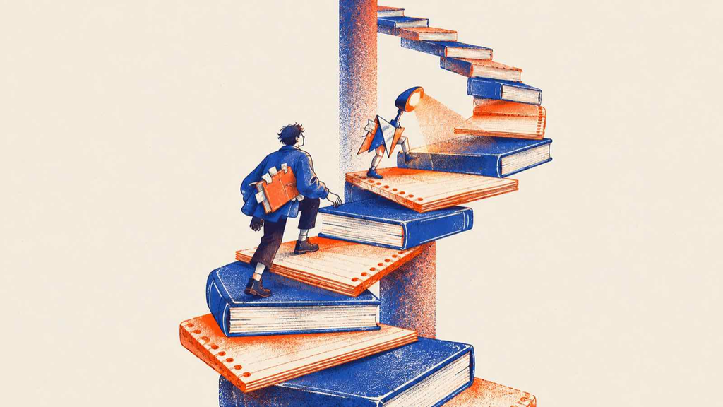

Question and literature

## Each one steers the other

Not a question from thin air, nor one that waits for a systematic review.

1 · Draft a topic or question

2 · Search it: is it answered?

3 · Refine what remains, and repeat

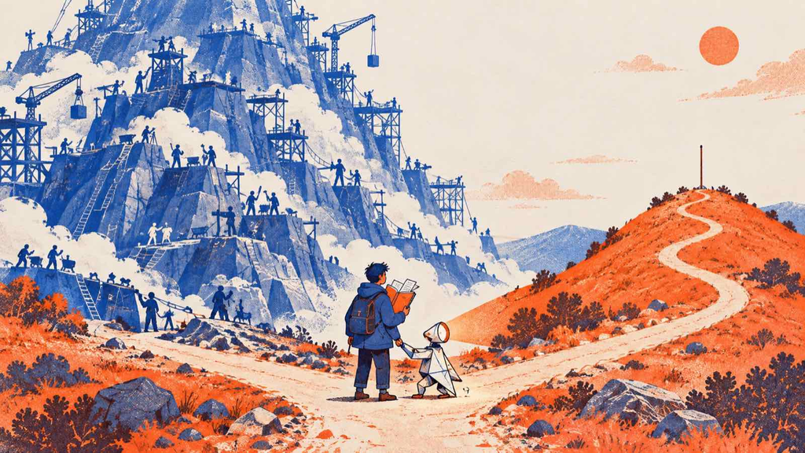

Practicalities

## Does it need an answer, and can you give one?

### So what?

Is the answer necessary, or does it provoke a shrug?

### Doable?

Or would it take 100 years, a billion dollars, a vast team?

### Within reach?

Methods you know, data you can actually access.

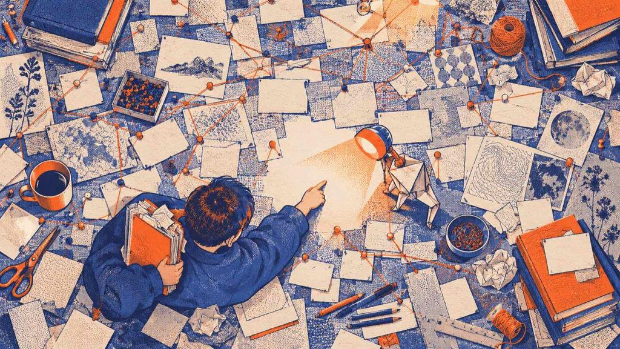

Novelty

## Has it been answered before?

- Often not obvious: many literatures and disciplines work on related problems
- Is it novel for good reasons, or because no one needs it, or research can’t answer it?
- Will it stay novel while you work?

“No one has studied the impact of [next year’s model] on student learning” — true until it’s released.

Breakout groups

## Everyone needs a candidate question.

It doesn’t need to be your dissertation

Work on a pseudo-topic together

Test it against sources, practicalities and novelty

Write it down in the class workspace

If time permits · about 25 minutes

## How the breakout works

1 Join your breakout room (Rooms 1–4)

2 Open the class doc → **Week 1 Collaboration**

3 Agree a pseudo-topic and a candidate question

4 Test it: sources, practicalities, novelty, and an AI stress-test

5 Back at 7:35: one question per room

Class doc: first item in Course introduction on Canvas

[interactive chart not shown]

Class constellation · before Session 2

## Put your question on the map

1 Add your name, up to five interests and a one-sentence research topic.

2 Recent papers gather around each interest, coloured to match.

3 Open one, check it against the source, and see who shares your interests.

[Open the class constellation →](https://machinespirits.org/590-fall-2026/map)

Ungraded · this week

## Baseline reflection

What question do you want to investigate, and why does it matter?

What do you already know about the relevant literature?

What would change your current understanding?

How have you used AI in research, and what are you unsure about?

A short starting point to compare with your final review.

From the syllabus · before or during the first seminar

Before next Monday

## Readings and Task 1

Weber, M. (1946). Science as a vocation. In H. H. Gerth & C. Wright Mills (Eds.), *From Max Weber: Essays in sociology*. Oxford University Press, pp. 129–156. [Read online](https://archive.org/details/frommaxweberessa00webe/page/129/mode/2up)

University of Illinois Library. (n.d.). *Develop a topic and dissect your research question*. [library.illinois.edu](https://www.library.illinois.edu/tlas/instruction/i-need-to-2/topic-research-question/)

Task 1 · Ungraded

### Research topic and question

Due Monday 26 October, 11:59 PM Central, on Canvas.

A provisional question: its significance, feasibility and first sources, and what you’d need to read to refine it.

Next week · Article anatomy, review design, mapping a field

← → or click to step through · F full screen